# Wolbachia small RNA Project

Victor Abdallah Rogana

2023-10-26

## Detection and Quantification of Wolbachia and Its Influence on Viral Load in Mosquitoes Using Small RNA Libraries

This R Markdown document is part of a comprehensive bioinformatics project that encompasses a detection and quantification of Wolbachia’s presence and its impact on viral load in mosquitoes through the analysis of small RNA libraries.

### Detection of Wolbachia in small RNA libraries

In our controlled experiment, we analyzed 18 small RNA libraries from laboratory A. aegypti mosquitoes, comparing them to publicly available Ae. aegypti data. This control data included two groups: one treated with tetracycline to remove Wolbachia infection and the other untreated.

We indexed 67 complete Wolbachia strain genomes from Refseq for alignment. The heatmap below shows two distinct clusters: infected and uninfected groups. Notably, only the 9 untreated mosquito libraries exhibited Wolbachia small RNAs, specific to the wAlb strain used for infection.

```r
# Data treatment to make the Heatmap
library(dplyr)
library(ggplot2)
library(reshape2)
library(ComplexHeatmap)
library(circlize)
library(viridis)
library(readxl)

# Load Data
counts_av0 <- read.delim("C:\\Users\\victo\\Desktop\\pasta_compartilhada\\reads_perwolb_controle_aedes_a_v0.tab", header = FALSE)
Aegypti_controle_a_v0 <- read.csv("C:\\Users\\victo\\Desktop\\pasta_compartilhada\\Aegypti_controle_a_v0.csv")
wolbs_reduced <- read_xlsx("C:\\Users\\victo\\Downloads\\wolbs_reduced_2.xlsx")

# Data Preparation
colnames(counts_av0) <- c("V1", "V2", "V3")
counts_av0 <- left_join(counts_av0, select(Aegypti_controle_a_v0, Library, total_reads_trimmed, tratamento_tetraciclina), by = c("V3" = "Library"))
counts_av0$rpm <- counts_av0$V1 / counts_av0$total_reads_trimmed * 1e6
counts_av0$corrected <- sub("NZ_", "", counts_av0$V2)
counts_av0 <- left_join(counts_av0, select(wolbs_reduced, AccessionVersion,Title_reduced), by = c("corrected"="AccessionVersion"))

# Prepare data for heatmap
d_counts_av0 <- counts_av0 %>% dcast(V3 + tratamento_tetraciclina ~ corrected + Title_reduced, value.var = "rpm")
d_counts_av0[is.na(d_counts_av0)] <- 0
d_counts_av0_matrix <- as.matrix(d_counts_av0[, c(-1, -2)])
row.names(d_counts_av0_matrix) <- paste0(d_counts_av0[, 1], "_", d_counts_av0[, 2])
```

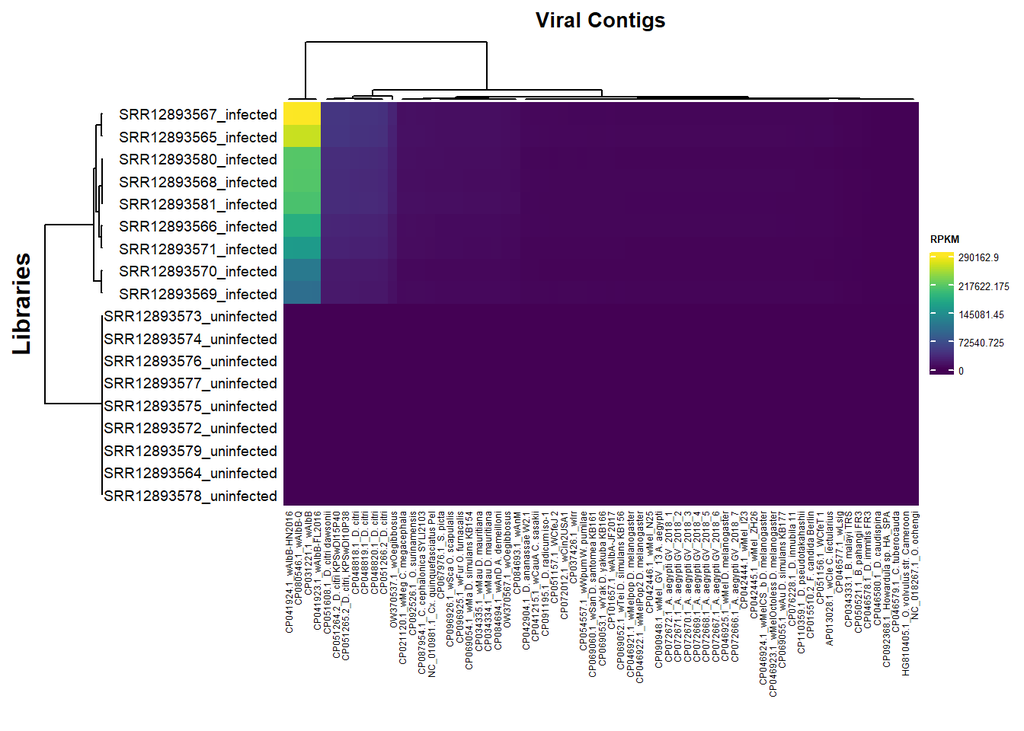

```r
# Heatmap code
Heatmap(d_counts_av0_matrix,
            heatmap_legend_param = list(color_bar = "continuous",
                                        at = c(0, round(max(d_counts_av0_matrix), 1) * 0.25, round(max(d_counts_av0_matrix), 1) * 0.5, round(max(d_counts_av0_matrix), 1) * 0.75, round(max(d_counts_av0_matrix), 1)),
                                        title_gp = gpar(fontsize = 5, fontface = "bold"),
                                        labels_gp = gpar(fontsize = 5)),
            name = "RPKM",
            row_labels = row.names(d_counts_av0_matrix),
            row_title = "Libraries",
            row_title_gp = gpar(fontsize = 12, fontface = "bold"),
            row_dend_side = "left",
            row_names_side = "left",
            row_names_gp = gpar(fontsize = 7),
            column_labels = colnames(d_counts_av0_matrix),
            column_title = "Viral Contigs",
            column_title_gp = gpar(fontsize = 10, fontface = "bold"),
            column_names_gp = gpar(fontsize = 4.5),
            clustering_distance_rows = "manhattan", # default is euclidean
            clustering_method_rows = "ward.D", # default is complete
            clustering_distance_col = "euclidean", # default is euclidean
            clustering_method_col = "complete", # default is complete,
            col = viridis(100)
)
```

### Using our strategy in field-collected mosquitoes

We extend the scope of our investigation to field-collected mosquitoes, where we deploy our detection and quantification strategy to assess the prevalence of Wolbachia across diverse mosquito species. A total of 85 small RNA libraries were examined, including:

- 17 libraries from Aedes albopictus
- 56 libraries from Aedes aegypti
- 4 libraries from Aedes japonicus
- 5 libraries from Haemagogus sp.
- 2 libraries from Sabethes sp.
- 1 library from Aedes vexans

Our findings provide the distribution of Wolbachia across these mosquito species, at least for this 67 strains of Wolbachia. Notably, only libraries derived from Aedes albopictus, exhibited significant Wolbachia alignments.

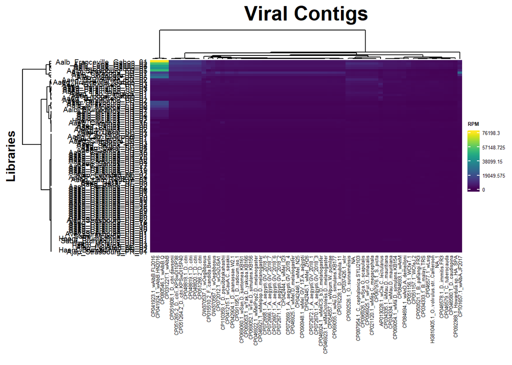

```r
# Load Data
rbind_noSPO_matrix_nome_reduzido <- read.csv("C:\\Users\\victo\\Documents\\rbind_no_SPO_matrix.csv", header = TRUE, row.names = 1)
rbind_noSPO_matrix_nome_reduzido = as.matrix(rbind_noSPO_matrix_nome_reduzido)

# Heatmap Code
set.seed(123)
p = Heatmap(rbind_noSPO_matrix_nome_reduzido,
          heatmap_legend_param = list(color_bar = "continuous",
                                      at = c(0,round(max(rbind_noSPO_matrix_nome_reduzido),1)*0.25,round(max(rbind_noSPO_matrix_nome_reduzido),1)*0.5,round(max(rbind_noSPO_matrix_nome_reduzido),1)*0.75,round(max(rbind_noSPO_matrix_nome_reduzido),1)),
                                      title_gp = gpar(fontsize = 5 , fontface = "bold"),labels_gp = gpar(fontsize = 5)),
          name = "RPM",
          row_labels = row.names(rbind_noSPO_matrix_nome_reduzido),
          row_title = "Libraries",
          row_title_gp = gpar(fontsize = 12, fontface = "bold"), row_dend_side = "left", row_names_side = "left",
          row_names_gp = gpar(fontsize = 7),
          column_labels = colnames(rbind_noSPO_matrix_nome_reduzido),column_title = "Viral Contigs",
          column_title_gp = gpar(fontsize = 20, fontface = "bold"),column_names_gp = gpar(fontsize = 5),
          clustering_distance_rows = "manhattan", #default eh euclidean
          clustering_method_rows = "ward.D", #default eh complete
          clustering_distance_col = "euclidean", #default eh euclidean
          clustering_method_col = "complete",#default eh complete
          col=viridis(100)
          #bottom_annotation = h,
)
p
```

### Looking only at the A. albopictus libraries

In the Zikallience Data, it was employed oxidation to prepare some of the libraries of Aedes albopictus. This technique selectively removes non-canonical small RNAs from the mosquito’s immune response, with the aim of shedding light on the RNAi pathway.

Comparing these oxidation libraries to control libraries, we found insignificant alignment in the libraries treated with oxidation. This result suggests that what we observed may not be the output of RNAi pathway, but rather a random enzymatic degradation process.

```r
# Data treatment to make the Heatmap
library(dplyr)
library(ggplot2)
library(reshape2)
library(ComplexHeatmap)
library(circlize)
library(viridis)
library(readxl)

# Load Data
wolbs_reduced = read_xlsx("C:\\Users\\victo\\Downloads\\wolbs_reduced_2.xlsx")
libs_name_jp_thesis = read.delim("C:\\Users\\victo\\Downloads\\libs_tese.tab", header = T)
counts = read.delim("C:\\Users\\victo\\Desktop\\pasta_compartilhada\\reads_perwolb_zika_allience_albopictus_a_v0.tab", header = F)
Albopictus_zika_allience_a_v0 = read.csv("C:\\Users\\victo\\Documents\\Albopictus_zika_allience_a_v0.csv")

# Data Preparation
counts = left_join(counts, select(Albopictus_zika_allience_a_v0,Library,`Library.Treatment`,total_reads_trimmed, Country), by = c("V3"="Library"))
counts$rpm = counts$V1/counts$total_reads_trimmed*1e6
counts$corrected = sub("NZ_","",counts$V2)
counts = left_join(counts, select(wolbs_reduced,AccessionVersion,Title_reduced), by = c("corrected"="AccessionVersion"))
counts = left_join(counts, select(libs_name_jp_thesis,internal_code,formal_label), by = c("V3"="internal_code"))

# Prepare Data for Heatmap
d_counts = counts %>% dcast(formal_label+`Library.Treatment`~corrected+Title_reduced, value.var = "rpm")
d_counts[is.na(d_counts)] = 0 #linhas com NAs recebem 0
d_counts_matrix = as.matrix(d_counts[,c(-1,-2)])
row.names(d_counts_matrix) = paste0(d_counts[,1],"_",d_counts[,2])
```

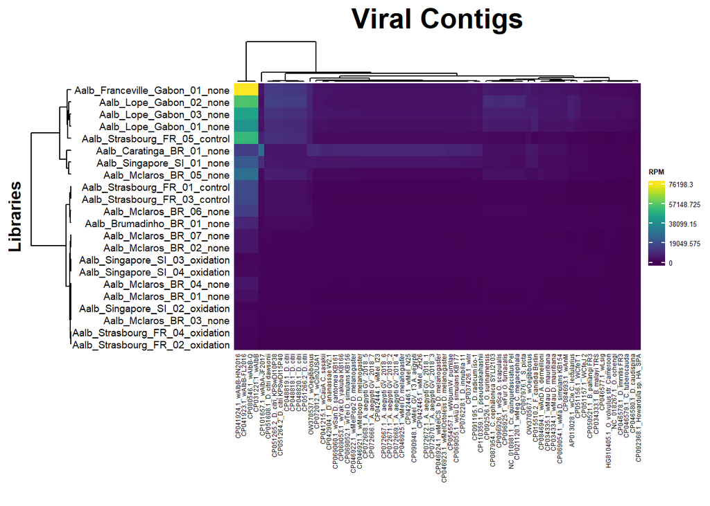

```r
# Heatmap code
set.seed(123)

p=Heatmap(d_counts_matrix,
          heatmap_legend_param = list(color_bar = "continuous",
                                      at = c(0,round(max(d_counts_matrix),1)*0.25,round(max(d_counts_matrix),1)*0.5,round(max(d_counts_matrix),1)*0.75,round(max(d_counts_matrix),1)),
                                      title_gp = gpar(fontsize = 5 , fontface = "bold"),labels_gp = gpar(fontsize = 5)),
          name = "RPM",
          row_labels = row.names(d_counts_matrix),
          row_title = "Libraries",
          row_title_gp = gpar(fontsize = 12, fontface = "bold"), row_dend_side = "left", row_names_side = "left",
          row_names_gp = gpar(fontsize = 7),
          column_labels = colnames(d_counts_matrix),column_title = "Viral Contigs",
          column_title_gp = gpar(fontsize = 20, fontface = "bold"),column_names_gp = gpar(fontsize = 4.5),
          clustering_distance_rows = "manhattan", #default eh euclidean
          clustering_method_rows = "ward.D", #default eh complete
          clustering_distance_col = "euclidean", #default eh euclidean
          clustering_method_col = "complete",#default eh complete
          col=viridis(100)
          #bottom_annotation = h,
)
p
```

### Deploying our Strategy in the Luciano Data

In the Luciano project, the introduction of the Wolbachia bacterium, specifically the wMel strain, into Aedes aegypti mosquitoes in specific regions was implemented. This introduction was carried out with the intention of reducing the mosquitoes’ capability to transmit diseases like dengue and other arboviruses.

In parallel, a control region was maintained where Aedes aegypti mosquitoes remained uninfected, providing a reference point for the strategy of mosquito release. We applied our method of detection in their data as we can see in the plot below.

```r
# Data treatment to make the Heatmap
library(dplyr)
library(ggplot2)
library(reshape2)
library(ComplexHeatmap)
library(circlize)
library(viridis)
library(readxl)

# Load Data
counts_niteroi = read.delim("C:\\Users\\victo\\Desktop\\pasta_compartilhada\\reads_perwolb_niteroi_av0.tab", header = F)
data_niteroi = read_xlsx("C:\\Users\\victo\\Downloads\\data_niteroi.xlsx")
wolbs_reduced = read_xlsx("C:\\Users\\victo\\Downloads\\wolbs_reduced_2.xlsx")

# Data Preparation
counts_niteroi <- counts_niteroi %>% filter(!V3 %in% c("RNPM221", "RNPM222", "RNPM223", "RNPM224")) #remove bee libraries
counts_niteroi = left_join(counts_niteroi, data_niteroi, by = c("V3"="V1"))
counts_niteroi$rpm = counts_niteroi$V1/counts_niteroi$V2.y*1e6
counts_niteroi$corrected = sub("NZ_","",counts_niteroi$V2.x)
counts_niteroi = left_join(counts_niteroi, select(wolbs_reduced,AccessionVersion,Title_reduced), by = c("corrected"="AccessionVersion"))
d_counts_niteroi = counts_niteroi %>% dcast(V3~corrected+Title_reduced, value.var = "rpm")
d_counts_niteroi[is.na(d_counts_niteroi)] = 0 #linhas com NAs recebem 0

# Prepare to plot
d_counts_niteroi_matrix = as.matrix(d_counts_niteroi[,-1])
row.names(d_counts_niteroi_matrix) = paste0(d_counts_niteroi[,1])
```

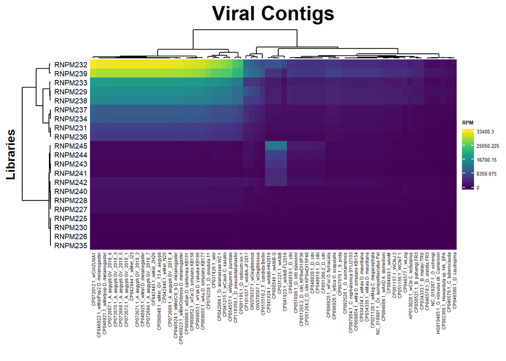

```r
# Plot Heatmap
set.seed(123)
p=Heatmap(d_counts_niteroi_matrix,
          heatmap_legend_param = list(color_bar = "continuous",
                                      at = c(0,round(max(d_counts_niteroi_matrix),1)*0.25,round(max(d_counts_niteroi_matrix),1)*0.5,round(max(d_counts_niteroi_matrix),1)*0.75,round(max(d_counts_niteroi_matrix),1)),
                                      title_gp = gpar(fontsize = 5 , fontface = "bold"),labels_gp = gpar(fontsize = 5)),
          name = "RPM",
          row_labels = row.names(d_counts_niteroi_matrix),
          row_title = "Libraries",
          row_title_gp = gpar(fontsize = 12, fontface = "bold"), row_dend_side = "left", row_names_side = "left",
          row_names_gp = gpar(fontsize = 7),
          column_labels = colnames(d_counts_niteroi_matrix),column_title = "Viral Contigs",
          column_title_gp = gpar(fontsize = 20, fontface = "bold"),column_names_gp = gpar(fontsize = 4.5),
          clustering_distance_rows = "manhattan", #default eh euclidean
          clustering_method_rows = "ward.D", #default eh complete
          clustering_distance_col = "euclidean", #default eh euclidean
          clustering_method_col = "complete",#default eh complete
          col=viridis(100)
          #bottom_annotation = h,
)
p
```

## Viral load Infected vs. Uninfected

###Heatmap_controle_viral_contigs

```r
library(dplyr)
library(ggplot2)
library(reshape2)
library(ComplexHeatmap)
library(viridis)

# Load Data
counts_viral_controle = read.delim("C:\\Users\\victo\\Desktop\\pasta_compartilhada\\reads_percontig_controle_av1.tab", header = F) #contagens read per wolbachia per library geradas na servidora
merge_viral_contigs_lenght = read.csv("C:\\Users\\victo\\Documents\\merge_viral_contig_leght.csv")
Aegypti_controle_a_v0 = read.csv("C:\\Users\\victo\\Desktop\\pasta_compartilhada\\Aegypti_controle_a_v0.csv")
data_controle = select(Aegypti_controle_a_v0,Library,total_reads_trimmed,tratamento_tetraciclina,Days)

# Data wrangling
counts_data_viral_controle = left_join(counts_viral_controle, data_controle, by = c("V3"="Library"))
counts_data_viral_controle = inner_join(counts_data_viral_controle, merge_viral_contigs_lenght, by = c("V2" = "V1"))

counts_data_viral_controle$total_reads_trimmed <- as.numeric(counts_data_viral_controle$total_reads_trimmed)
counts_data_viral_controle$V2.y <- as.numeric(counts_data_viral_controle$V2.y)
counts_data_viral_controle$V1 <- as.numeric(counts_data_viral_controle$V1)
counts_data_viral_controle$rpm = counts_data_viral_controle$V1/counts_data_viral_controle$total_reads_trimmed*1e6
counts_data_viral_controle$rpkm <- (counts_data_viral_controle$V1 * 1e9) /
  (counts_data_viral_controle$total_reads_trimmed * counts_data_viral_controle$V2.y)

# Prepering for Heatmap plot
d_counts_data_viral_controle = counts_data_viral_controle %>% dcast(V3+tratamento_tetraciclina+Days~V2, value.var = "rpkm")
d_counts_data_viral_controle[is.na(d_counts_data_viral_controle)] = 0 #tirando a linha com os NAs
d_counts_data_viral_controle_matrix = as.matrix(d_counts_data_viral_controle[,c(-1,-2,-3)])
row.names(d_counts_data_viral_controle_matrix) = paste0(d_counts_data_viral_controle[,1],"_",d_counts_data_viral_controle[,2],"_",d_counts_data_viral_controle[,3])
```

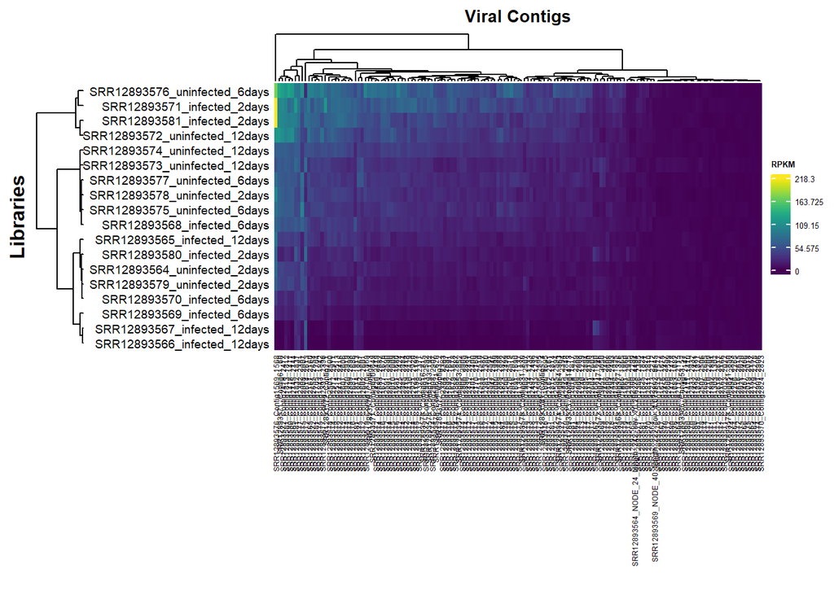

```r
p = Heatmap(d_counts_data_viral_controle_matrix,
        heatmap_legend_param = list(color_bar = "continuous",
                                    at = c(0, round(max(d_counts_data_viral_controle_matrix), 1) * 0.25, round(max(d_counts_data_viral_controle_matrix), 1) * 0.5, round(max(d_counts_data_viral_controle_matrix), 1) * 0.75, round(max(d_counts_data_viral_controle_matrix), 1)),
                                    title_gp = gpar(fontsize = 5, fontface = "bold"),
                                    labels_gp = gpar(fontsize = 5)),
        name = "RPKM",
        row_labels = row.names(d_counts_data_viral_controle_matrix),
        row_title = "Libraries",
        row_title_gp = gpar(fontsize = 12, fontface = "bold"),
        row_dend_side = "left",
        row_names_side = "left",
        row_names_gp = gpar(fontsize = 7),
        column_labels = colnames(d_counts_data_viral_controle_matrix),
        column_title = "Viral Contigs",
        column_title_gp = gpar(fontsize = 10, fontface = "bold"),
        column_names_gp = gpar(fontsize = 4.5),
        clustering_distance_rows = "manhattan", # default is euclidean
        clustering_method_rows = "ward.D", # default is complete
        clustering_distance_col = "euclidean", # default is euclidean
        clustering_method_col = "complete", # default is complete,
        col = viridis(100)
)
p
```

### Distribution of RPKM (boxplots)

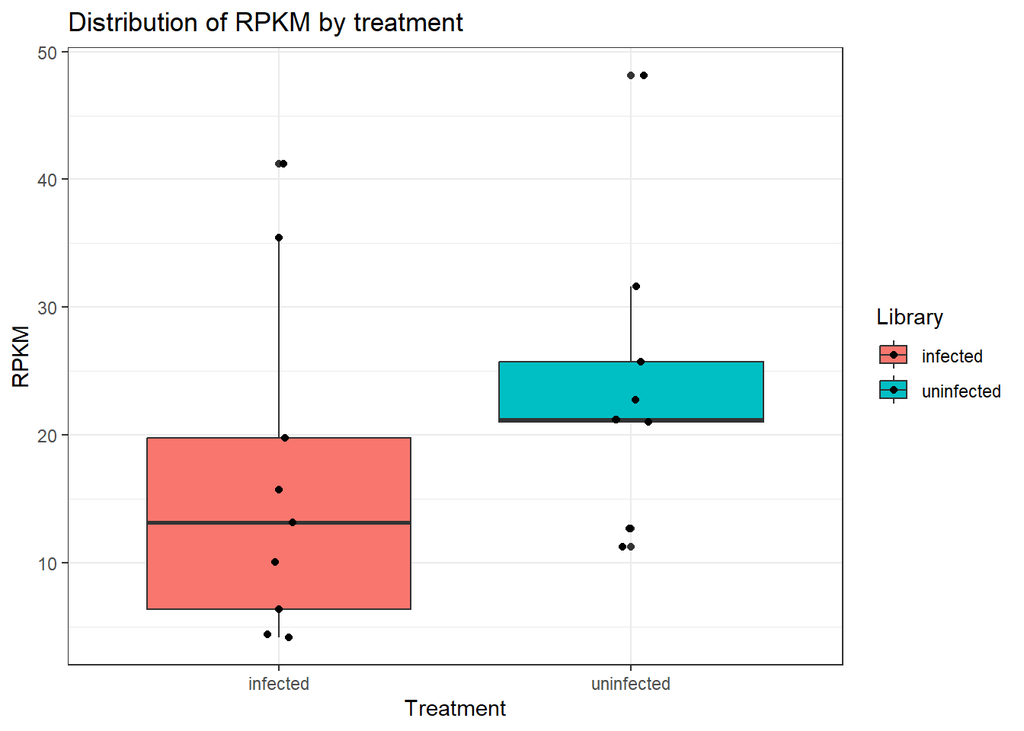

```r
# Libraries
library(dplyr)
library(ggplot2)
library(reshape2)
library(ComplexHeatmap)
# Load Data
counts_data_viral_controle = read.csv("C:\\Users\\victo\\Documents\\counts_data_viral_controle.csv")

library_RPKM <- aggregate(rpkm ~ V3, counts_data_viral_controle, mean)
library_RPKM = left_join(library_RPKM, data_controle, by = c("V3"="Library"))
library_RPKM_median <- aggregate(rpkm ~ V3, counts_data_viral_controle, median)
library_RPKM_median = left_join(library_RPKM_median, data_controle, by = c("V3"="Library"))

ggplot(library_RPKM, aes(x = tratamento_tetraciclina, y = rpkm, fill = tratamento_tetraciclina)) +
  geom_boxplot() +
  geom_point(position = position_jitterdodge(dodge.width = 0.75, jitter.width = 0.1)) +
  labs(x = "Treatment", y = "RPKM", fill = "Library") +
  ggtitle("Distribution of RPKM by treatment") +
  theme(legend.position = "bottom") +
  scale_fill_discrete(name = "Library") +
  theme_bw()
```

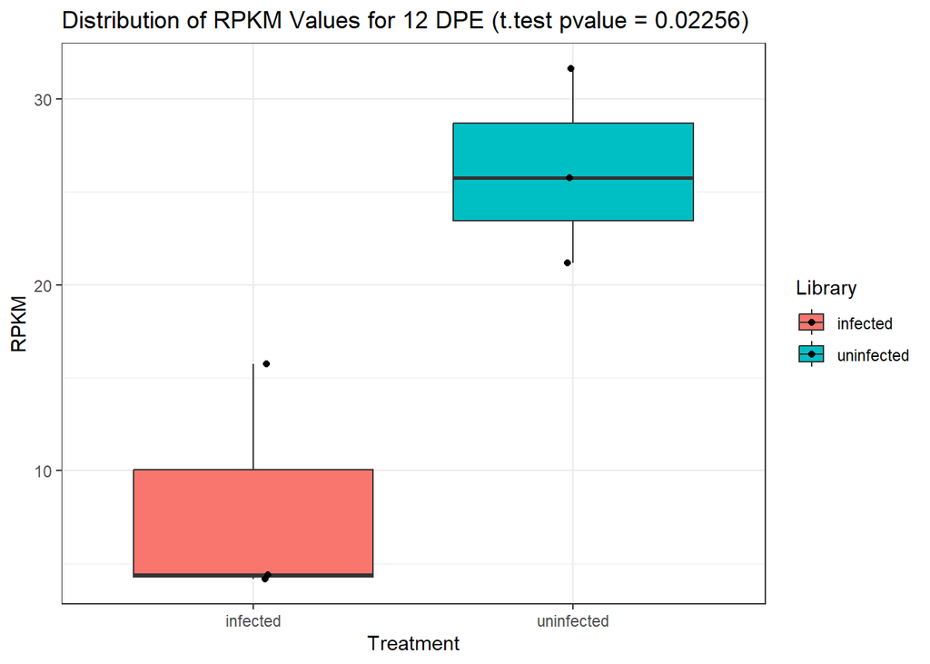

```r
library_RPKM %>%
  filter(Days == "12days") %>%
  ggplot(aes(x = tratamento_tetraciclina, y = rpkm, fill = tratamento_tetraciclina)) +
  geom_boxplot() +
  geom_point(position = position_jitterdodge(dodge.width = 0.75, jitter.width = 0.1)) +
  labs(x = "Treatment", y = "RPKM", fill = "Library") +
  ggtitle("Distribution of RPKM Values for 12 DPE (t.test pvalue = 0.02256)") +
  theme(legend.position = "bottom") +
  scale_fill_discrete(name = "Library") +
  theme_bw()
```

### Statistical Tests

```r
counts_data_2days <- filter(library_RPKM, Days == "2days")
counts_data_6days <- filter(library_RPKM, Days == "6days")
counts_data_12days <- filter(library_RPKM, Days == "12days")

t.test(rpkm ~ tratamento_tetraciclina, data = library_RPKM)
```

```
##
##  Welch Two Sample t-test
##
## data:  rpkm by tratamento_tetraciclina
## t = -1.2592, df = 15.4, p-value = 0.2267
## alternative hypothesis: true difference in means between group infected and group uninfected is not equal to 0
## 95 percent confidence interval:
##  -19.531046   5.003484
## sample estimates:
##   mean in group infected mean in group uninfected
##                 16.70008                 23.96386
```

```r
t.test(rpkm ~ tratamento_tetraciclina, data = counts_data_12days)
```

```
##
##  Welch Two Sample t-test
##
## data:  rpkm by tratamento_tetraciclina
## t = -3.7096, df = 3.806, p-value = 0.02256
## alternative hypothesis: true difference in means between group infected and group uninfected is not equal to 0
## 95 percent confidence interval:
##  -31.892250  -4.272113
## sample estimates:
##   mean in group infected mean in group uninfected
##                 8.105452                26.187633
```

```r
# Fit the ANOVA model
model <- aov(rpkm ~ tratamento_tetraciclina, data = library_RPKM)
summary(model)
```

```
##                         Df Sum Sq Mean Sq F value Pr(>F)
## tratamento_tetraciclina  1  237.4   237.4   1.586  0.226
## Residuals               16 2395.7   149.7
```

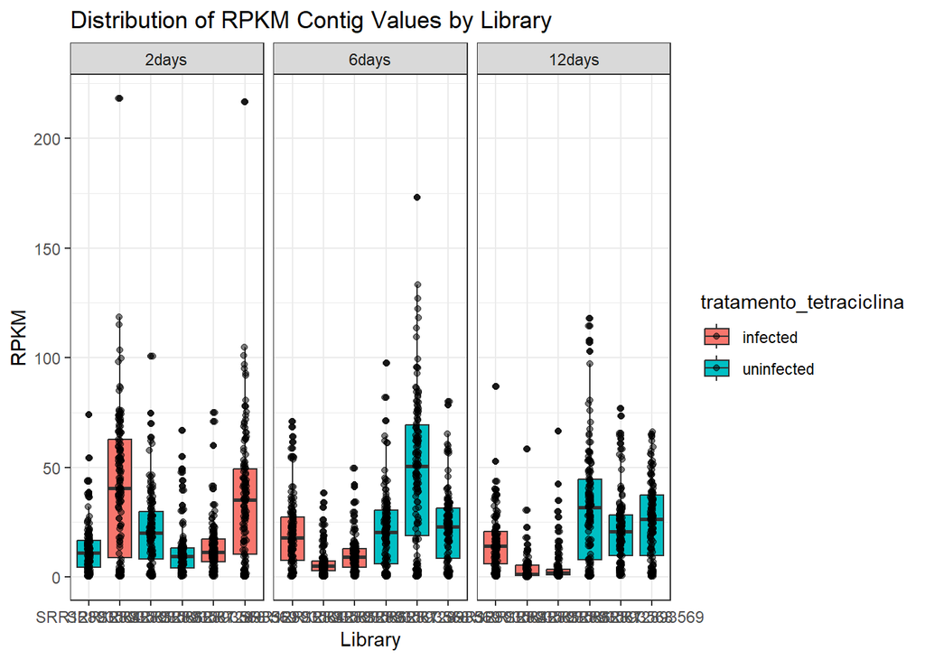

```r
# Reorder the factor levels for Days and tratamento_tetraciclina
counts_data_viral_controle$Days <- factor(counts_data_viral_controle$Days, levels = c("2days", "6days", "12days"))

p <- ggplot(counts_data_viral_controle, aes(x = V3, y = rpkm, fill = tratamento_tetraciclina)) +
  geom_boxplot() +
  geom_jitter(position = position_jitter(width = 0.05), alpha = 0.5) +
  scale_x_discrete(labels = library_RPKM$V3) +
  labs(x = "Library", y = "RPKM") +
  ggtitle("Distribution of RPKM Contig Values by Library") +
  theme_bw() +
  facet_grid(. ~ Days, scales = "free_x")

p
```

## Counting Aligned Genes with HTSeq

To delve deeper into the genes of Wolbachia present in the libraries from different sources, we used HTSeq to quantify the genes of aligned reads in various datasets. Our analysis encompassed three key library types:

- Laboratory Aedes aegypti Control: These libraries served as a baseline for our investigation, representing controlled conditions.
- Field-Collected Albopictus Zikalliance: Libraries from field-collected Aedes albopictus within the Zikalliance project.
- Field-Collected A. aegypti Luciano: Libraries derived from Aedes aegypti in the Luciano project, which included Wolbachia-infected mosquitoes.

### HTseq Laboratory A. aegypti Control

```r
# Data treatment to make the Heatmap
library(dplyr)
library(ggplot2)
library(reshape2)
library(ComplexHeatmap)
library(circlize)
library(viridis)
library(readxl)

#Load Data
counts_intersection_strict_walb_9x9 = read.delim("C:\\Users\\victo\\Desktop\\pasta_compartilhada\\htseq_intersection-strict_walb_9x9.tab", header = F)
tamanho_gene_walb = read.csv("C:\\Users\\victo\\Documents\\tamanho_gene_walb.csv")
size_infected_library = read.csv("C:\\Users\\victo\\Documents\\size_infected_library.csv")
gene_product_walb = read.csv("C:\\Users\\victo\\Documents\\gene_product_walb.csv")

# Data preparation
colnames(counts_intersection_strict_walb_9x9) [1] <- "gene"
colnames(counts_intersection_strict_walb_9x9) [2] <- "counts"
colnames(counts_intersection_strict_walb_9x9) [3] <- "library"
counts_intersection_strict_walb_9x9 = left_join(counts_intersection_strict_walb_9x9, size_infected_library, by = "library") #pegando contagem reads mapeadas e metadados (merge nos dados)
counts_intersection_strict_walb_9x9 = left_join(counts_intersection_strict_walb_9x9, tamanho_gene_walb, by = "gene")
counts_intersection_strict_walb_9x9$rpkm = counts_intersection_strict_walb_9x9$counts/((counts_intersection_strict_walb_9x9$gene_lenght/1e3)*(counts_intersection_strict_walb_9x9$size_of_library/1e6)) #calculando o RPKM
counts_intersection_strict_walb_9x9 = left_join(counts_intersection_strict_walb_9x9, gene_product_walb, by="gene")
#Transformando dataframe para plotar heatmap
d_counts_intersection_strict_walb_9x9 = counts_intersection_strict_walb_9x9 %>% dcast(product~library, value.var = "rpkm", fun.aggregate = mean) #dcast fazendo matriz de RPM
d_counts_intersection_strict_walb_9x9[is.na(d_counts_intersection_strict_walb_9x9)] = 0 #linhas com NAs recebem 0

#organizando para plotar:
d_counts_intersection_strict_walb_9x9_matrix = as.matrix(d_counts_intersection_strict_walb_9x9[,-1]) #retirando a primeira coluna
row.names(d_counts_intersection_strict_walb_9x9_matrix) = d_counts_intersection_strict_walb_9x9[,1] #transformando a primeira coluna em nome das linhas
```

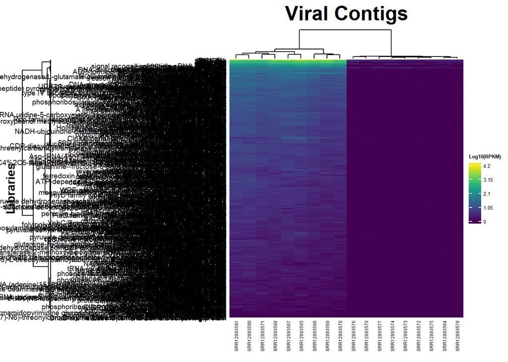

```r
#log10_matrix
log_data_9x9_matrix <- log10(d_counts_intersection_strict_walb_9x9_matrix + 1)

p=Heatmap(log_data_9x9_matrix,
          heatmap_legend_param = list(color_bar = "continuous",
                                      at = c(0,round(max(log_data_9x9_matrix),1)*0.25,round(max(log_data_9x9_matrix),1)*0.5,round(max(log_data_9x9_matrix),1)*0.75,round(max(log_data_9x9_matrix),1)),
                                      title_gp = gpar(fontsize = 5 , fontface = "bold"),labels_gp = gpar(fontsize = 5)),
          name = "Log10(RPKM)",
          row_labels = row.names(log_data_9x9_matrix),
          row_title = "Libraries",
          row_title_gp = gpar(fontsize = 12, fontface = "bold"), row_dend_side = "left", row_names_side = "left",
          row_names_gp = gpar(fontsize = 7),
          column_labels = colnames(log_data_9x9_matrix),column_title = "Viral Contigs",
          column_title_gp = gpar(fontsize = 20, fontface = "bold"),column_names_gp = gpar(fontsize = 4.5),
          clustering_distance_rows = "manhattan", #default eh euclidean
          clustering_method_rows = "ward.D", #default eh complete
          clustering_distance_col = "euclidean", #default eh euclidean
          clustering_method_col = "complete",#default eh complete
          col=viridis(100)
          #bottom_annotation = h,
)
p
```

### HTseq Field-Collected Albopictus Zikalliance

```r
# Data treatment to make the Heatmap
library(dplyr)
library(ggplot2)
library(reshape2)
library(ComplexHeatmap)
library(circlize)
library(viridis)
library(readxl)

# Load Data
htseq_intersection_strict_zikallience_alb_k1_v0 = read.csv("C:\\Users\\victo\\Downloads\\htseq_intersection_strict_zikallience_alb_k1_v0.csv")
size_of_libraries_walb = read.csv("C:\\Users\\victo\\Downloads\\size_of_libraries_walb.csv")
gene_lenght_walb = read.csv("C:\\Users\\victo\\Downloads\\gene_lenght_walb.csv")
gene_product_walbB_completo = read.csv("C:\\Users\\victo\\Downloads\\gene_product_walbB_completo.csv")

# Prepare Data
counts_zika_allience_alb = left_join(htseq_intersection_strict_zikallience_alb_k1_v0, size_of_libraries_walb, by = "library") #pegando contagem reads trimadas per library e metadata
counts_zika_allience_alb = left_join(counts_zika_allience_alb, gene_lenght_walb, by = "gene")
counts_zika_allience_alb = left_join(counts_zika_allience_alb, select(gene_product_walbB_completo,gene,product), by = "gene")
counts_zika_allience_alb$rpkm = counts_zika_allience_alb$counts/((counts_zika_allience_alb$gene_lenght/1e3)*(counts_zika_allience_alb$size_of_library/1e6)) #calculando o RPKM

# Transformando dataframe para plotar heatmap
d_counts_zika_allience_alb = counts_zika_allience_alb %>% dcast(product~library, value.var = "rpkm", fun.aggregate = mean)
d_counts_zika_allience_alb[is.na(d_counts_zika_allience_alb)] = 0

#organizando para plotar

d_counts_zika_allience_alb_matrix = as.matrix(d_counts_zika_allience_alb[,c(-1,-2)]) #retirando a primeira coluna
row.names(d_counts_zika_allience_alb_matrix) = paste0(d_counts_zika_allience_alb[,1],"_",d_counts_zika_allience_alb[,2]) #transformando a primeira coluna em nome das linhas\
```

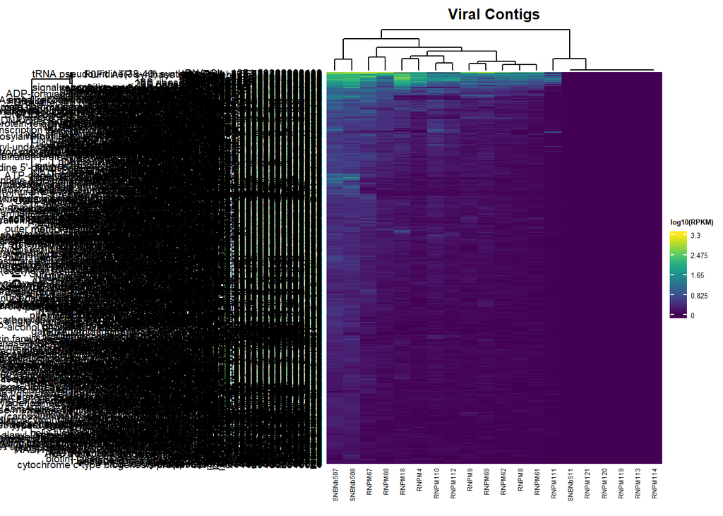

```r
# log 10
d_counts_zika_allience_alb_matrix_log10 = log10(d_counts_zika_allience_alb_matrix + 1)

# Heatmap Code
p=Heatmap(d_counts_zika_allience_alb_matrix_log10,
          heatmap_legend_param = list(color_bar = "continuous",
                                      at = c(0,round(max(d_counts_zika_allience_alb_matrix_log10),1)*0.25,round(max(d_counts_zika_allience_alb_matrix_log10),1)*0.5,round(max(d_counts_zika_allience_alb_matrix_log10),1)*0.75,round(max(d_counts_zika_allience_alb_matrix_log10),1)),
                                      title_gp = gpar(fontsize = 5 , fontface = "bold"),labels_gp = gpar(fontsize = 5)),
          name = "log10(RPKM)",
          row_labels = row.names(d_counts_zika_allience_alb_matrix_log10),
          row_title = "Libraries",
          row_title_gp = gpar(fontsize = 12, fontface = "bold"), row_dend_side = "left", row_names_side = "left",
          row_names_gp = gpar(fontsize = 7),
          column_labels = colnames(d_counts_zika_allience_alb_matrix_log10),column_title = "Viral Contigs",
          column_title_gp = gpar(fontsize = 10, fontface = "bold"),column_names_gp = gpar(fontsize = 4.5),
          clustering_distance_rows = "manhattan", #default eh euclidean
          clustering_method_rows = "ward.D", #default eh complete
          clustering_distance_col = "euclidean", #default eh euclidean
          clustering_method_col = "complete",#default eh complete
          col=viridis(100)
          #bottom_annotation = h,
)
p
```

### Field-Collected A. aegypti Luciano

```r
# Data treatment to make the Heatmap
library(dplyr)
library(ggplot2)
library(reshape2)
library(ComplexHeatmap)
library(circlize)
library(viridis)
library(readxl)

##########Htseq_niteroi################
data_niteroi = read.delim("C:\\Users\\victo\\Documents\\data_niteroi.csv", header = T, sep = ",")
counts_intersection_strict_niteroi = read.delim("C:\\Users\\victo\\Downloads\\htseq_intersection-strict_wmel_k1_v0.tab", header = T)
gene_lenght_wmel = read.delim("C:\\Users\\victo\\Downloads\\gene_lengths.tab", header = T)
gene_product_wmel = read.delim("C:\\Users\\victo\\Downloads\\gene_product_wmel.tab", header = T)
coverage_wsp_niteroi = read.delim("C:\\Users\\victo\\Documents\\coverage_wsp_niteroi.csv", header = T, sep = ",") #just to get the "Name" column of this dataframe

counts_intersection_strict_niteroi = left_join(counts_intersection_strict_niteroi, data_niteroi, by = "library") #pegando contagem reads mapeadas e metadados (merge nos dados)
counts_intersection_strict_niteroi = left_join(counts_intersection_strict_niteroi, gene_lenght_wmel, by = "gene")
counts_intersection_strict_niteroi$rpkm = counts_intersection_strict_niteroi$counts/((counts_intersection_strict_niteroi$gene_size/1e3)*(counts_intersection_strict_niteroi$library_size/1e6)) #calculando o RPKM
counts_intersection_strict_niteroi = left_join(counts_intersection_strict_niteroi, gene_product_wmel, by="gene")
counts_intersection_strict_niteroi <- left_join(counts_intersection_strict_niteroi,
                                                select(coverage_wsp_niteroi, Code, Name),
                                                by = c("library" = "Code"))

#Transformando dataframe para plotar heatmap
d_counts_intersection_strict_niteroi = counts_intersection_strict_niteroi %>% dcast(product~Name, value.var = "rpkm", fun.aggregate = mean) #dcast fazendo matriz de RPM
d_counts_intersection_strict_niteroi[is.na(d_counts_intersection_strict_niteroi)] = 0 #linhas com NAs recebem 0

# Organizando pra plotar
d_counts_intersection_strict_niteroi_matrix <- as.matrix(d_counts_intersection_strict_niteroi[,-1])
row_names <- paste(d_counts_intersection_strict_niteroi[, 1])
row.names(d_counts_intersection_strict_niteroi_matrix) <- row_names
```

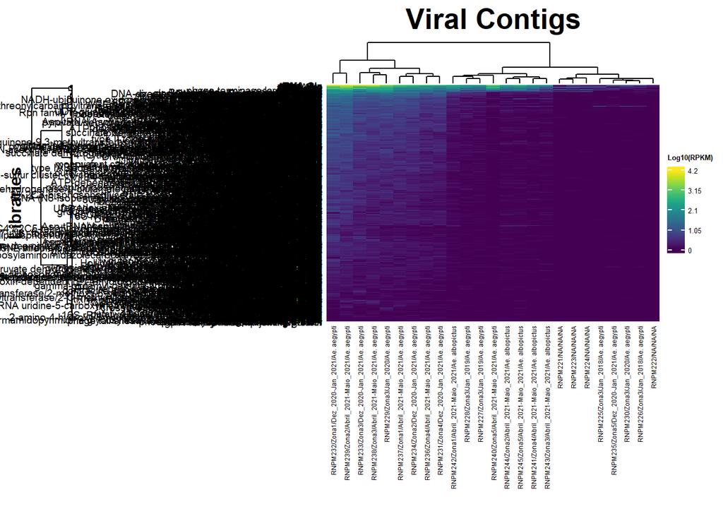

```r
#log10_matrix
log_niteroi_data_9x9_matrix <- log10(d_counts_intersection_strict_niteroi_matrix + 1)

p=Heatmap(log_niteroi_data_9x9_matrix,
          heatmap_legend_param = list(color_bar = "continuous",
                                      at = c(0,round(max(log_niteroi_data_9x9_matrix),1)*0.25,round(max(log_niteroi_data_9x9_matrix),1)*0.5,round(max(log_niteroi_data_9x9_matrix),1)*0.75,round(max(log_niteroi_data_9x9_matrix),1)),
                                      title_gp = gpar(fontsize = 5 , fontface = "bold"),labels_gp = gpar(fontsize = 5)),
          name = "Log10(RPKM)",
          row_labels = row.names(log_niteroi_data_9x9_matrix),
          row_title = "Libraries",
          row_title_gp = gpar(fontsize = 12, fontface = "bold"), row_dend_side = "left", row_names_side = "left",
          row_names_gp = gpar(fontsize = 7),
          column_labels = colnames(log_niteroi_data_9x9_matrix),column_title = "Viral Contigs",
          column_title_gp = gpar(fontsize = 20, fontface = "bold"),column_names_gp = gpar(fontsize = 4.5),
          clustering_distance_rows = "manhattan", #default eh euclidean
          clustering_method_rows = "ward.D", #default eh complete
          clustering_distance_col = "euclidean", #default eh euclidean
          clustering_method_col = "complete",#default eh complete
          col=viridis(100)
          #bottom_annotation = h,
)
p
```

##Heatmap with Annotation of coverage/rpm (specific genes)

### Coverage

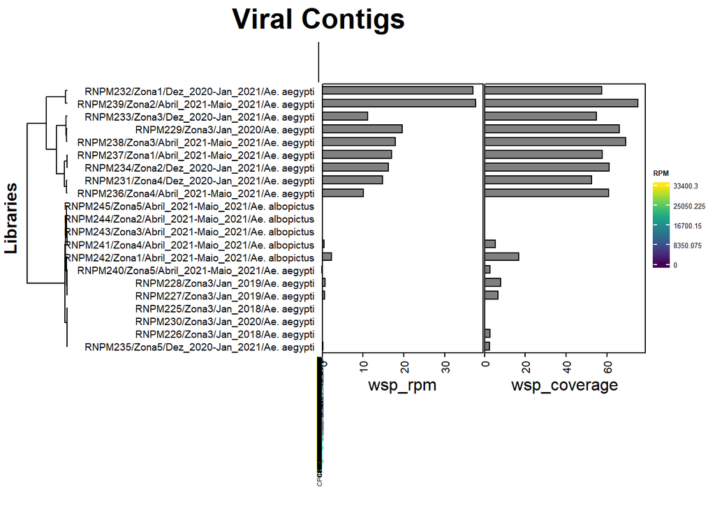

```r
# Loading data
data_niteroi = read_xlsx("C:\\Users\\victo\\Downloads\\data_niteroi.xlsx")
metadata_niteroi = read_xlsx("C:\\Users\\victo\\Downloads\\Metadados_Niteroi_wolb.xlsx")
coverage_wsp_niteroi = read.delim("C:\\Users\\victo\\Downloads\\all_coverage_data.tab")
counts_wsp_niteroi = read.delim("C:\\Users\\victo\\Downloads\\reads_wsp_wmel_luciano.tab", header = T)
counts_niteroi = read.delim("C:\\Users\\victo\\Desktop\\pasta_compartilhada\\reads_perwolb_niteroi_av0.tab", header = F) #contagens read per wolbachia per library geradas na servidora

# Preparing data
coverage_wsp_niteroi <- left_join(coverage_wsp_niteroi, metadata_niteroi, by = "Code")
coverage_wsp_niteroi$Name <- with(coverage_wsp_niteroi, paste(Code, Zona, Periodo_coleta, Mosquito, sep="/"))

counts_wsp_niteroi <- left_join(counts_wsp_niteroi, metadata_niteroi, by = "Code")
counts_wsp_niteroi$Name <- with(counts_wsp_niteroi, paste(Code, Zona, Periodo_coleta, Mosquito, sep="/"))
counts_wsp_niteroi = left_join(counts_wsp_niteroi, data_niteroi, by = c("Code"="V1")) #pegando contagem reads trimadas per library e metadata
counts_wsp_niteroi$rpm = counts_wsp_niteroi$counts/counts_wsp_niteroi$V2*1e6

# Heatmap code
counts_niteroi = left_join(counts_niteroi, data_niteroi, by = c("V3"="V1")) #pegando contagem reads trimadas per library e metadata
counts_niteroi$rpm = counts_niteroi$V1/counts_niteroi$V2.y*1e6
counts_niteroi$corrected = sub("NZ_","",counts_niteroi$V2.x) #corrigindo para pegar descricoes das wolbachias
counts_niteroi = left_join(counts_niteroi, select(wolbs_reduced,AccessionVersion,Title_reduced), by = c("corrected"="AccessionVersion"))
counts_niteroi = left_join(counts_niteroi, select(coverage_wsp_niteroi, Name, Code), by = c("V3"="Code"))

#removendo abelhas
remove_samples <- c("RNPM221", "RNPM222", "RNPM223", "RNPM224") # List of RNPM to remove

# Filter counts_niteroi
counts_niteroi <- counts_niteroi[!counts_niteroi$V3 %in% remove_samples, ]

# Filter counts_wsp_niteroi and coverage_wsp_niteroi before creating annotations
counts_wsp_niteroi_filtered <- counts_wsp_niteroi[!counts_wsp_niteroi$Code %in% remove_samples, ]
coverage_wsp_niteroi_filtered <- coverage_wsp_niteroi[!coverage_wsp_niteroi$Code %in% remove_samples, ]

#Transformando dataframe para plotar heatmap
d_counts_niteroi = counts_niteroi %>% dcast(Name~corrected+Title_reduced, value.var = "rpm")
d_counts_niteroi[is.na(d_counts_niteroi)] = 0 #linhas com NAs recebem 0

# Plotting heatmap with annotations
d_counts_niteroi_matrix = as.matrix(d_counts_niteroi[,-1])
row.names(d_counts_niteroi_matrix) = paste0(d_counts_niteroi[,1])

# Create the RPM annotation
anno_rpm <- anno_barplot(counts_wsp_niteroi_filtered$rpm, border = TRUE, width = unit(4, "cm"), which = "row")

# Create the coverage annotation
anno_coverage <- anno_barplot(coverage_wsp_niteroi_filtered$coverage, border = TRUE, width = unit(4, "cm"), which = "row")

#Plot heatmap
set.seed(123)

p=Heatmap(d_counts_niteroi_matrix,
          heatmap_legend_param = list(color_bar = "continuous",
                                      at = c(0,round(max(d_counts_niteroi_matrix),1)*0.25,round(max(d_counts_niteroi_matrix),1)*0.5,round(max(d_counts_niteroi_matrix),1)*0.75,round(max(d_counts_niteroi_matrix),1)),
                                      title_gp = gpar(fontsize = 5 , fontface = "bold"),labels_gp = gpar(fontsize = 5)),
          name = "RPM",
          row_labels = row.names(d_counts_niteroi_matrix),
          row_title = "Libraries",
          row_title_gp = gpar(fontsize = 12, fontface = "bold"), row_dend_side = "left", row_names_side = "left",
          row_names_gp = gpar(fontsize = 7),
          column_labels = colnames(d_counts_niteroi_matrix),column_title = "Viral Contigs",
          column_title_gp = gpar(fontsize = 20, fontface = "bold"),column_names_gp = gpar(fontsize = 4.5),
          clustering_distance_rows = "manhattan", #default eh euclidean
          clustering_method_rows = "ward.D", #default eh complete
          clustering_distance_col = "euclidean", #default eh euclidean
          clustering_method_col = "complete",#default eh complete
          col=viridis(100)
          #bottom_annotation = h,
)
# Combine the heatmap with the annotations
ht_list <- p + rowAnnotation(wsp_rpm = anno_rpm, wsp_coverage = anno_coverage)
draw(ht_list)
```

###

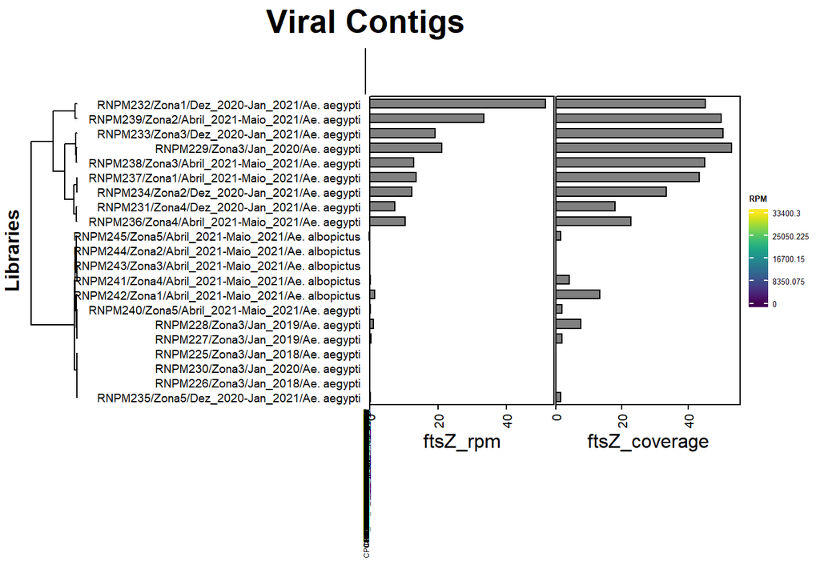

```r
# Loading data
metadata_niteroi = read_xlsx("C:\\Users\\victo\\Downloads\\Metadados_Niteroi_wolb.xlsx")
coverage_ftsZ_niteroi = read.delim("C:\\Users\\victo\\Downloads\\all_coverage_data_ftsZ.tab")
counts_ftsZ_niteroi = read.delim("C:\\Users\\victo\\Downloads\\reads_ftsZ_wmel_luciano.tab", header = F)
data_niteroi = read_xlsx("C:\\Users\\victo\\Downloads\\data_niteroi.xlsx")
counts_niteroi = read.delim("C:\\Users\\victo\\Desktop\\pasta_compartilhada\\reads_perwolb_niteroi_av0.tab", header = F) #contagens read per wolbachia per library geradas na servidora

# Preparing data
coverage_ftsZ_niteroi <- left_join(coverage_ftsZ_niteroi, metadata_niteroi, by = "Code")
coverage_ftsZ_niteroi$Name <- with(coverage_ftsZ_niteroi, paste(Code, Zona, Periodo_coleta, Mosquito, sep="/"))

colnames(counts_ftsZ_niteroi)[1] <- "counts"
colnames(counts_ftsZ_niteroi)[3] <- "Code"
counts_ftsZ_niteroi <- left_join(counts_ftsZ_niteroi, metadata_niteroi, by = "Code")
counts_ftsZ_niteroi$Name <- with(counts_ftsZ_niteroi, paste(Code, Zona, Periodo_coleta, Mosquito, sep="/"))
counts_ftsZ_niteroi = left_join(counts_ftsZ_niteroi, data_niteroi, by = c("Code"="V1")) #pegando contagem reads trimadas per library e metadata
counts_ftsZ_niteroi$rpm = counts_ftsZ_niteroi$counts / counts_ftsZ_niteroi$V2.y * 1e6

counts_niteroi = left_join(counts_niteroi, data_niteroi, by = c("V3"="V1")) #pegando contagem reads trimadas per library e metadata
counts_niteroi$rpm = counts_niteroi$V1/counts_niteroi$V2.y*1e6
counts_niteroi$corrected = sub("NZ_","",counts_niteroi$V2.x) #corrigindo para pegar descricoes das wolbachias
counts_niteroi = left_join(counts_niteroi, select(wolbs_reduced,AccessionVersion,Title_reduced), by = c("corrected"="AccessionVersion"))
counts_niteroi = left_join(counts_niteroi, select(coverage_wsp_niteroi, Name, Code), by = c("V3"="Code"))

#removendo abelhas
remove_samples <- c("RNPM221", "RNPM222", "RNPM223", "RNPM224")# List of RNPM to remove

# Filter counts_niteroi
counts_niteroi <- counts_niteroi[!counts_niteroi$V3 %in% remove_samples, ]

# Filter counts_ftsZ_niteroi and coverage_wsp_niteroi before creating annotations
counts_ftsZ_niteroi_filtered <- counts_ftsZ_niteroi[!counts_ftsZ_niteroi$Code %in% remove_samples, ]
coverage_ftsZ_niteroi_filtered <- coverage_ftsZ_niteroi[!coverage_ftsZ_niteroi$Code %in% remove_samples, ]

#Transformando dataframe para plotar heatmap
d_counts_niteroi = counts_niteroi %>% dcast(Name~corrected+Title_reduced, value.var = "rpm")
d_counts_niteroi[is.na(d_counts_niteroi)] = 0 #linhas com NAs recebem 0
d_counts_niteroi_matrix = as.matrix(d_counts_niteroi[,-1])
row.names(d_counts_niteroi_matrix) = paste0(d_counts_niteroi[,1])

# Plotando heatamp com annotation

# Create the RPM annotation
anno_rpm <- anno_barplot(counts_ftsZ_niteroi_filtered$rpm, border = TRUE, width = unit(4, "cm"), which = "row")

# Create the coverage annotation
anno_coverage <- anno_barplot(coverage_ftsZ_niteroi_filtered$coverage, border = TRUE, width = unit(4, "cm"), which = "row")

#Plot heatmap
set.seed(123)

p=Heatmap(d_counts_niteroi_matrix,
          heatmap_legend_param = list(color_bar = "continuous",
                                      at = c(0,round(max(d_counts_niteroi_matrix),1)*0.25,round(max(d_counts_niteroi_matrix),1)*0.5,round(max(d_counts_niteroi_matrix),1)*0.75,round(max(d_counts_niteroi_matrix),1)),
                                      title_gp = gpar(fontsize = 5 , fontface = "bold"),labels_gp = gpar(fontsize = 5)),
          name = "RPM",
          row_labels = row.names(d_counts_niteroi_matrix),
          row_title = "Libraries",
          row_title_gp = gpar(fontsize = 12, fontface = "bold"), row_dend_side = "left", row_names_side = "left",
          row_names_gp = gpar(fontsize = 7),
          column_labels = colnames(d_counts_niteroi_matrix),column_title = "Viral Contigs",
          column_title_gp = gpar(fontsize = 20, fontface = "bold"),column_names_gp = gpar(fontsize = 4.5),
          clustering_distance_rows = "manhattan", #default eh euclidean
          clustering_method_rows = "ward.D", #default eh complete
          clustering_distance_col = "euclidean", #default eh euclidean
          clustering_method_col = "complete",#default eh complete
          col=viridis(100)
          #bottom_annotation = h,
)
# Combine the heatmap with the annotations
ht_list <- p + rowAnnotation(ftsZ_rpm = anno_rpm, ftsZ_coverage = anno_coverage)
draw(ht_list)
```

### heatmap anno fbpA

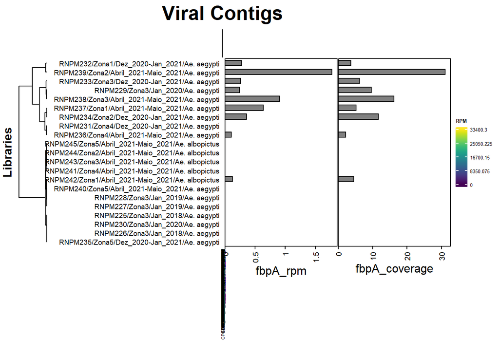

```r
# Loading Data
metadata_niteroi = read_xlsx("C:\\Users\\victo\\Downloads\\Metadados_Niteroi_wolb.xlsx")
coverage_fbpA_niteroi = read.delim("C:\\Users\\victo\\Downloads\\all_coverage_data_fbpA.tab")
counts_fbpA_niteroi = read.delim("C:\\Users\\victo\\Downloads\\reads_fbpA_wmel_luciano.tab", header = F)
counts_niteroi = read.delim("C:\\Users\\victo\\Desktop\\pasta_compartilhada\\reads_perwolb_niteroi_av0.tab", header = F) #contagens read per wolbachia per library geradas na servidora
data_niteroi = read_xlsx("C:\\Users\\victo\\Downloads\\data_niteroi.xlsx")

# Preparing Data
coverage_fbpA_niteroi <- left_join(coverage_fbpA_niteroi, metadata_niteroi, by = "Code")
coverage_fbpA_niteroi$Name <- with(coverage_fbpA_niteroi, paste(Code, Zona, Periodo_coleta, Mosquito, sep="/"))

colnames(counts_fbpA_niteroi)[1] <- "counts"
colnames(counts_fbpA_niteroi)[3] <- "Code"
counts_fbpA_niteroi <- left_join(counts_fbpA_niteroi, metadata_niteroi, by = "Code")
counts_fbpA_niteroi$Name <- with(counts_fbpA_niteroi, paste(Code, Zona, Periodo_coleta, Mosquito, sep="/"))
counts_fbpA_niteroi = left_join(counts_fbpA_niteroi, data_niteroi, by = c("Code"="V1")) #pegando contagem reads trimadas per library e metadata
counts_fbpA_niteroi$rpm = counts_fbpA_niteroi$counts / counts_fbpA_niteroi$V2.y * 1e6

counts_niteroi = left_join(counts_niteroi, data_niteroi, by = c("V3"="V1")) #pegando contagem reads trimadas per library e metadata
counts_niteroi$rpm = counts_niteroi$V1/counts_niteroi$V2.y*1e6
counts_niteroi$corrected = sub("NZ_","",counts_niteroi$V2.x) #corrigindo para pegar descricoes das wolbachias
counts_niteroi = left_join(counts_niteroi, select(wolbs_reduced,AccessionVersion,Title_reduced), by = c("corrected"="AccessionVersion"))
counts_niteroi = left_join(counts_niteroi, select(coverage_wsp_niteroi, Name, Code), by = c("V3"="Code"))

#removendo abelhas
remove_samples <- c("RNPM221", "RNPM222", "RNPM223", "RNPM224")# List of RNPM to remove

# Filter counts_niteroi
counts_niteroi <- counts_niteroi[!counts_niteroi$V3 %in% remove_samples, ]

# Filter counts_ftsZ_niteroi and coverage_wsp_niteroi before creating annotations
counts_fbpA_niteroi_filtered <- counts_fbpA_niteroi[!counts_fbpA_niteroi$Code %in% remove_samples, ]
coverage_fbpA_niteroi_filtered <- coverage_fbpA_niteroi[!coverage_fbpA_niteroi$Code %in% remove_samples, ]
#Transformando dataframe para plotar heatmap
d_counts_niteroi = counts_niteroi %>% dcast(Name~corrected+Title_reduced, value.var = "rpm")
d_counts_niteroi[is.na(d_counts_niteroi)] = 0 #linhas com NAs recebem 0
d_counts_niteroi_matrix = as.matrix(d_counts_niteroi[,-1])
row.names(d_counts_niteroi_matrix) = paste0(d_counts_niteroi[,1])
d_counts_niteroi_matrix = as.matrix(d_counts_niteroi[,-1])
row.names(d_counts_niteroi_matrix) = paste0(d_counts_niteroi[,1])
# Create the RPM annotation
anno_rpm <- anno_barplot(counts_fbpA_niteroi_filtered$rpm, border = TRUE, width = unit(4, "cm"), which = "row")

# Create the coverage annotation
anno_coverage <- anno_barplot(coverage_fbpA_niteroi_filtered$coverage, border = TRUE, width = unit(4, "cm"), which = "row")

#Plot heatmap
set.seed(123)

p=Heatmap(d_counts_niteroi_matrix,
          heatmap_legend_param = list(color_bar = "continuous",
                                      at = c(0,round(max(d_counts_niteroi_matrix),1)*0.25,round(max(d_counts_niteroi_matrix),1)*0.5,round(max(d_counts_niteroi_matrix),1)*0.75,round(max(d_counts_niteroi_matrix),1)),
                                      title_gp = gpar(fontsize = 5 , fontface = "bold"),labels_gp = gpar(fontsize = 5)),
          name = "RPM",
          row_labels = row.names(d_counts_niteroi_matrix),
          row_title = "Libraries",
          row_title_gp = gpar(fontsize = 12, fontface = "bold"), row_dend_side = "left", row_names_side = "left",
          row_names_gp = gpar(fontsize = 7),
          column_labels = colnames(d_counts_niteroi_matrix),column_title = "Viral Contigs",
          column_title_gp = gpar(fontsize = 20, fontface = "bold"),column_names_gp = gpar(fontsize = 4.5),
          clustering_distance_rows = "manhattan", #default eh euclidean
          clustering_method_rows = "ward.D", #default eh complete
          clustering_distance_col = "euclidean", #default eh euclidean
          clustering_method_col = "complete",#default eh complete
          col=viridis(100)
          #bottom_annotation = h,
)
# Combine the heatmap with the annotations
ht_list <- p + rowAnnotation(fbpA_rpm = anno_rpm, fbpA_coverage = anno_coverage)
draw(ht_list)
```

### Heatmap Annotation ctaD

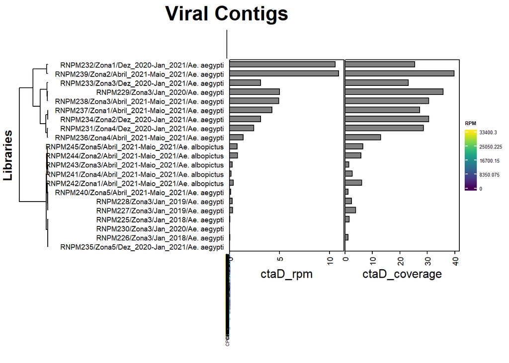

```r
# Loading Data
metadata_niteroi = read_xlsx("C:\\Users\\victo\\Downloads\\Metadados_Niteroi_wolb.xlsx")
coverage_ctaD_niteroi = read.delim("C:\\Users\\victo\\Downloads\\all_coverage_data_ctaD.tab")
counts_ctaD_niteroi = read.delim("C:\\Users\\victo\\Downloads\\reads_ctaD_wmel_luciano.tab", header = F)
counts_niteroi = read.delim("C:\\Users\\victo\\Desktop\\pasta_compartilhada\\reads_perwolb_niteroi_av0.tab", header = F) #contagens read per wolbachia per library geradas na servidora
data_niteroi = read_xlsx("C:\\Users\\victo\\Downloads\\data_niteroi.xlsx")

# Preparing Data
coverage_ctaD_niteroi <- left_join(coverage_ctaD_niteroi, metadata_niteroi, by = "Code")
coverage_ctaD_niteroi$Name <- with(coverage_ctaD_niteroi, paste(Code, Zona, Periodo_coleta, Mosquito, sep="/"))

colnames(counts_ctaD_niteroi)[1] <- "counts"
colnames(counts_ctaD_niteroi)[3] <- "Code"
counts_ctaD_niteroi <- left_join(counts_ctaD_niteroi, metadata_niteroi, by = "Code")
counts_ctaD_niteroi$Name <- with(counts_ctaD_niteroi, paste(Code, Zona, Periodo_coleta, Mosquito, sep="/"))
counts_ctaD_niteroi = left_join(counts_ctaD_niteroi, data_niteroi, by = c("Code"="V1")) #pegando contagem reads trimadas per library e metadata
counts_ctaD_niteroi$rpm = counts_ctaD_niteroi$counts / counts_ctaD_niteroi$V2.y * 1e6

counts_niteroi = left_join(counts_niteroi, data_niteroi, by = c("V3"="V1")) #pegando contagem reads trimadas per library e metadata
counts_niteroi$rpm = counts_niteroi$V1/counts_niteroi$V2.y*1e6
counts_niteroi$corrected = sub("NZ_","",counts_niteroi$V2.x) #corrigindo para pegar descricoes das wolbachias
counts_niteroi = left_join(counts_niteroi, select(wolbs_reduced,AccessionVersion,Title_reduced), by = c("corrected"="AccessionVersion"))
counts_niteroi = left_join(counts_niteroi, select(coverage_wsp_niteroi, Name, Code), by = c("V3"="Code"))

#removendo abelhas
remove_samples <- c("RNPM221", "RNPM222", "RNPM223", "RNPM224")# List of RNPM to remove

# Filter counts_niteroi
counts_niteroi <- counts_niteroi[!counts_niteroi$V3 %in% remove_samples, ]

# Filter counts_ftsZ_niteroi and coverage_wsp_niteroi before creating annotations
counts_ctaD_niteroi_filtered <- counts_ctaD_niteroi[!counts_ctaD_niteroi$Code %in% remove_samples, ]
coverage_ctaD_niteroi_filtered <- coverage_ctaD_niteroi[!coverage_ctaD_niteroi$Code %in% remove_samples, ]
#Transformando dataframe para plotar heatmap
d_counts_niteroi = counts_niteroi %>% dcast(Name~corrected+Title_reduced, value.var = "rpm")
d_counts_niteroi[is.na(d_counts_niteroi)] = 0 #linhas com NAs recebem 0
d_counts_niteroi_matrix = as.matrix(d_counts_niteroi[,-1])
row.names(d_counts_niteroi_matrix) = paste0(d_counts_niteroi[,1])

# Create the RPM annotation
anno_rpm <- anno_barplot(counts_ctaD_niteroi_filtered$rpm, border = TRUE, width = unit(4, "cm"), which = "row")

# Create the coverage annotation
anno_coverage <- anno_barplot(coverage_ctaD_niteroi_filtered$coverage, border = TRUE, width = unit(4, "cm"), which = "row")

#Plot heatmap
set.seed(123)

p=Heatmap(d_counts_niteroi_matrix,
          heatmap_legend_param = list(color_bar = "continuous",
                                      at = c(0,round(max(d_counts_niteroi_matrix),1)*0.25,round(max(d_counts_niteroi_matrix),1)*0.5,round(max(d_counts_niteroi_matrix),1)*0.75,round(max(d_counts_niteroi_matrix),1)),
                                      title_gp = gpar(fontsize = 5 , fontface = "bold"),labels_gp = gpar(fontsize = 5)),
          name = "RPM",
          row_labels = row.names(d_counts_niteroi_matrix),
          row_title = "Libraries",
          row_title_gp = gpar(fontsize = 12, fontface = "bold"), row_dend_side = "left", row_names_side = "left",
          row_names_gp = gpar(fontsize = 7),
          column_labels = colnames(d_counts_niteroi_matrix),column_title = "Viral Contigs",
          column_title_gp = gpar(fontsize = 20, fontface = "bold"),column_names_gp = gpar(fontsize = 4.5),
          clustering_distance_rows = "manhattan", #default eh euclidean
          clustering_method_rows = "ward.D", #default eh complete
          clustering_distance_col = "euclidean", #default eh euclidean
          clustering_method_col = "complete",#default eh complete
          col=viridis(100)
          #bottom_annotation = h,
)
# Combine the heatmap with the annotations
ht_list <- p + rowAnnotation(ctaD_rpm = anno_rpm, ctaD_coverage = anno_coverage)
draw(ht_list)
```